# Paper

Ainhoa Magrach

6 November 2018

# ABSTRACT

Natural ecosystems across the globe are increasingly suffering from the pressures of on-going global change. Pollinators, in particular, have been reported to decline in abundance and diversity in different parts of the world, with potential implications for many plant species given the dependence of 87.5% of plant species on pollinators for reproduction. Although a strong body of research has focused on pollinator visitation frequency and plant reproduction, most of these efforts have been done at the individual species level, largely ignoring community-level implications. Indeed, interaction network structure can affect pollinator functional roles, their visitation patterns to different plant species and ultimately the pollination service they deliver to plants. Thus, a major knowledge gap at the moment is a mechanistic understanding of how pollinator visitation and the structure of plant-pollinator visitation networks affect plant reproduction. Here, we use 16 well-resolved plant-pollinator networks from Mediterranean shrub ecosystems to evaluate how pollinator species diversity, community composition and interaction network structure affect plant reproduction for 19 species of plants. Further, we link pollinator visitation frequencies with the efficiency of individual pollinator species. To this end, we use data on fruit and seed set for all plant species as well as data on the efficiency of a single visit by different pollinator species on 12 of these plant species. This work represents one of the first efforts linking pollination visitation and plant reproduction from a community-wide perspective using a well-replicated dataset.

# METHODS

First, check sampling completeness

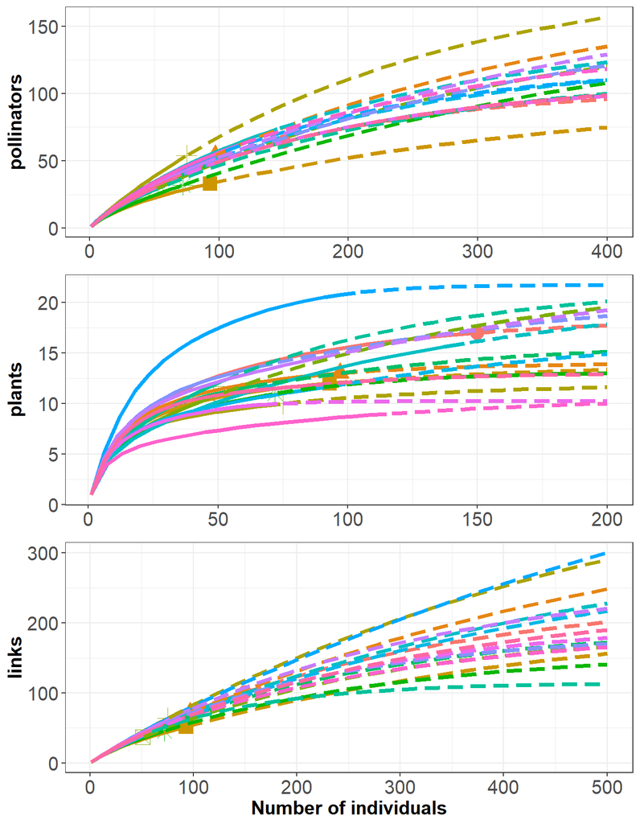

Average sampling completeness for pollinators = 0.35, range 18-62% plants= 0.78, range 47-98% links= 0.27, range 13-41%

### QUESTION 1:

What is the relationship between network structure and functioning?

Here, we will define network structure at the community (whole-network level) focusing in particular in two aspects: network nestedness (a measure of redundancy in species roles) and functional complementarity (a measure of complementarity in species niches). Functioning will be defined as average fruit set for each species at each site. Plant species will be included as a random factor to evaluate whether the reproductive success of different species change across networks with different overall structures. Models include nestedness, funct compl and their interaction. check best model with “dredge” and plot significant variables

#### Function as FRUITSET

```
##  Family: gaussian  ( identity )
## Formula:
## mean.fruitset ~ nodf.song * functional.comp.poll + (1 | Plant.sp)
## Data: f.agg2
##
##      AIC      BIC   logLik deviance df.resid
##     -3.9      6.2      8.0    -15.9       34
##
## Random effects:
##
## Conditional model:
##  Groups   Name        Variance Std.Dev.
##  Plant.sp (Intercept) 0.01335  0.1156
##  Residual             0.02979  0.1726
## Number of obs: 40, groups:  Plant.sp, 15
##
## Dispersion estimate for gaussian family (sigma^2): 0.0298
##
## Conditional model:
##                                 Estimate Std. Error z value Pr(>|z|)
## (Intercept)                    1.022e+00  6.734e-01   1.518    0.129
## nodf.song                      6.888e-01  2.240e+00   0.308    0.758
## functional.comp.poll           7.397e-05  1.029e-02   0.007    0.994
## nodf.song:functional.comp.poll 2.676e-03  3.291e-02   0.081    0.935
```

```
## Global model call: glmmTMB(formula = mean.fruitset ~ nodf.song * functional.comp.poll +
##     (1 | Plant.sp), data = f.agg2, family = "gaussian", ziformula = ~0,
##     dispformula = ~1)
## ---
## Model selection table
##   cnd((Int)) dsp((Int)) cnd(fnc.cmp.pll) cnd(ndf.sng)
## 3     1.0470          +                        0.9108
## 4     1.0760          +       -7.361e-04       0.8688
## 1     0.7594          +
## 8     1.0220          +        7.397e-05       0.6888
## 2     0.9603          +       -3.513e-03
##   cnd(fnc.cmp.pll:ndf.sng) df logLik AICc delta weight
## 3                           4  7.925 -6.7  0.00  0.672
## 4                           5  7.966 -4.2  2.54  0.189
## 1                           3  4.153 -1.6  5.07  0.053
## 8                 0.002676  6  7.969 -1.4  5.32  0.047
## 2                           4  5.086 -1.0  5.68  0.039
## Models ranked by AICc(x)
## Random terms (all models):
## 'cond(1 | Plant.sp)'
```

```
##  Family: gaussian  ( identity )
## Formula:          mean.fruitset ~ nodf.song + (1 | Plant.sp)
## Data: f.agg2
##
##      AIC      BIC   logLik deviance df.resid
##     -7.9     -1.1      7.9    -15.9       36
##
## Random effects:
##
## Conditional model:
##  Groups   Name        Variance Std.Dev.
##  Plant.sp (Intercept) 0.01339  0.1157
##  Residual             0.02986  0.1728
## Number of obs: 40, groups:  Plant.sp, 15
##
## Dispersion estimate for gaussian family (sigma^2): 0.0299
##
## Conditional model:
##             Estimate Std. Error z value Pr(>|z|)
## (Intercept)   1.0468     0.1075   9.738  < 2e-16 ***
## nodf.song     0.9108     0.3145   2.896  0.00377 **
## ---
## Signif. codes:  0 '***' 0.001 '**' 0.01 '*' 0.05 '.' 0.1 ' ' 1
```

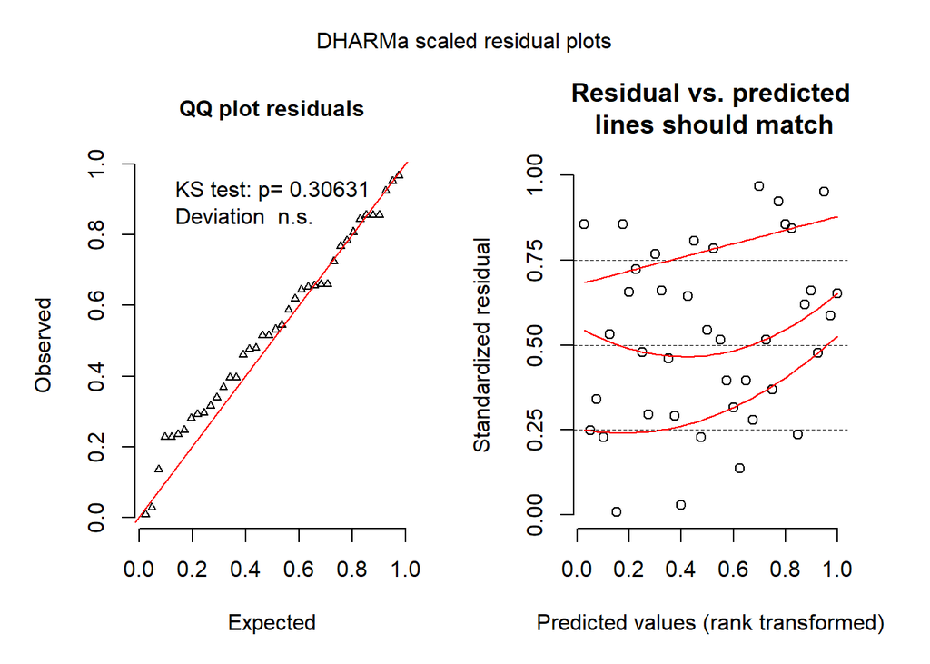

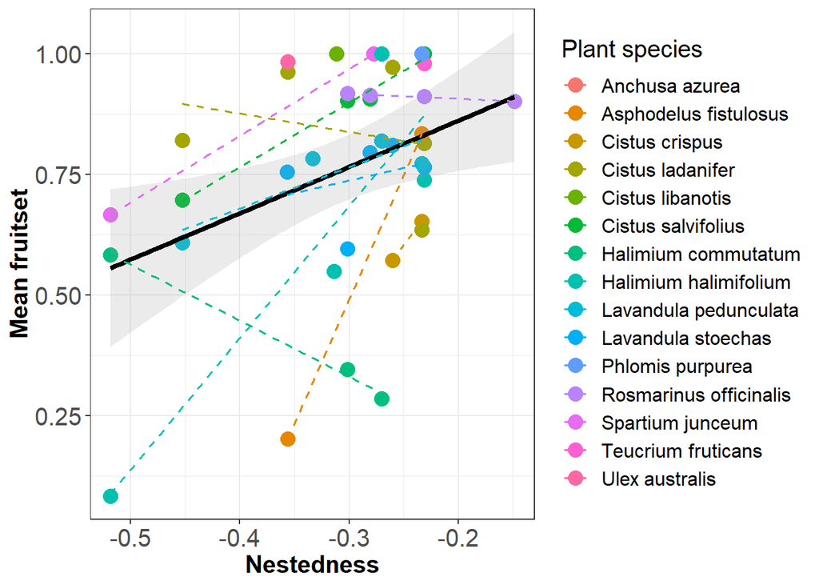

#### Function as SEED NUMBER

```
##  Family: poisson  ( log )
## Formula:
## mean.seednumber ~ nodf.song * functional.comp.poll + (1 | Plant.sp)
## Data: s.agg
##
##      AIC      BIC   logLik deviance df.resid
##    519.7    530.6   -254.8    509.7       60
##
## Random effects:
##
## Conditional model:
##  Groups   Name        Variance Std.Dev.
##  Plant.sp (Intercept) 2.281    1.51
## Number of obs: 65, groups:  Plant.sp, 19
##
## Conditional model:
##                                 Estimate Std. Error z value Pr(>|z|)
## (Intercept)                    -0.067886   0.744949  -0.091  0.92739
## nodf.song                      -3.804170   1.983004  -1.918  0.05506 .
## functional.comp.poll            0.028907   0.009844   2.937  0.00332 **
## nodf.song:functional.comp.poll  0.053403   0.028825   1.853  0.06393 .
## ---
## Signif. codes:  0 '***' 0.001 '**' 0.01 '*' 0.05 '.' 0.1 ' ' 1
```

```
## Global model call: glmmTMB(formula = mean.seednumber ~ nodf.song * functional.comp.poll +
##     (1 | Plant.sp), data = s.agg, family = "poisson", ziformula = ~0,
##     dispformula = ~1)
## ---
## Model selection table
##   cnd((Int)) dsp((Int)) cnd(fnc.cmp.pll) cnd(ndf.sng)
## 2    1.14500          +          0.01155
## 8   -0.06789          +          0.02891      -3.8040
## 4    1.12100          +          0.01108      -0.1581
## 3    1.60500          +                       -0.6101
## 1    1.80000          +
##   cnd(fnc.cmp.pll:ndf.sng) df   logLik  AICc delta weight
## 2                           3 -256.780 520.0  0.00  0.479
## 8                   0.0534  5 -254.843 520.7  0.75  0.330
## 4                           4 -256.562 521.8  1.84  0.191
## 3                           3 -270.740 547.9 27.92  0.000
## 1                           2 -274.191 552.6 32.62  0.000
## Models ranked by AICc(x)
## Random terms (all models):
## 'cond(1 | Plant.sp)'
```

```
##  Family: poisson  ( log )
## Formula:          mean.seednumber ~ functional.comp.poll + (1 | Plant.sp)
## Data: s.agg
##
##      AIC      BIC   logLik deviance df.resid
##    519.6    526.1   -256.8    513.6       62
##
## Random effects:
##
## Conditional model:
##  Groups   Name        Variance Std.Dev.
##  Plant.sp (Intercept) 2.267    1.506
## Number of obs: 65, groups:  Plant.sp, 19
##
## Conditional model:
##                      Estimate Std. Error z value Pr(>|z|)
## (Intercept)          1.144501   0.374480   3.056  0.00224 **
## functional.comp.poll 0.011553   0.001939   5.957 2.57e-09 ***
## ---
## Signif. codes:  0 '***' 0.001 '**' 0.01 '*' 0.05 '.' 0.1 ' ' 1
```

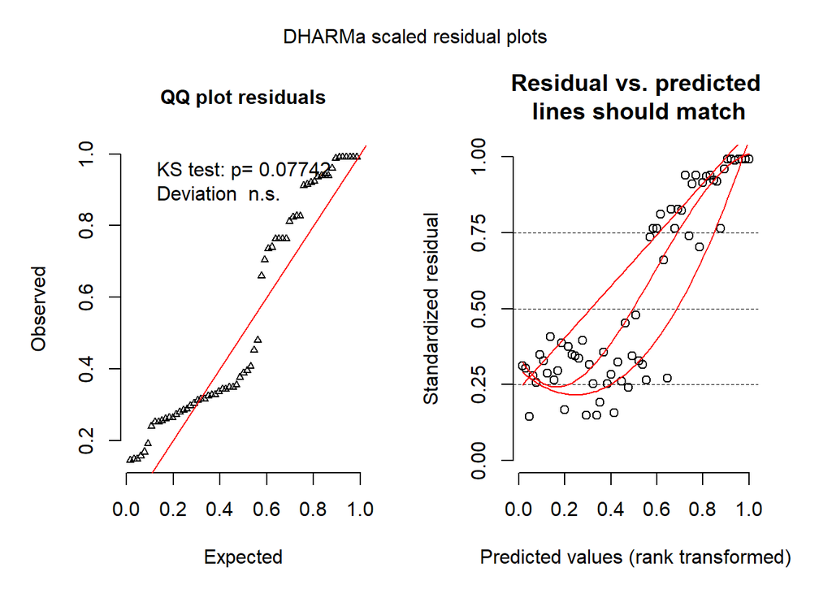

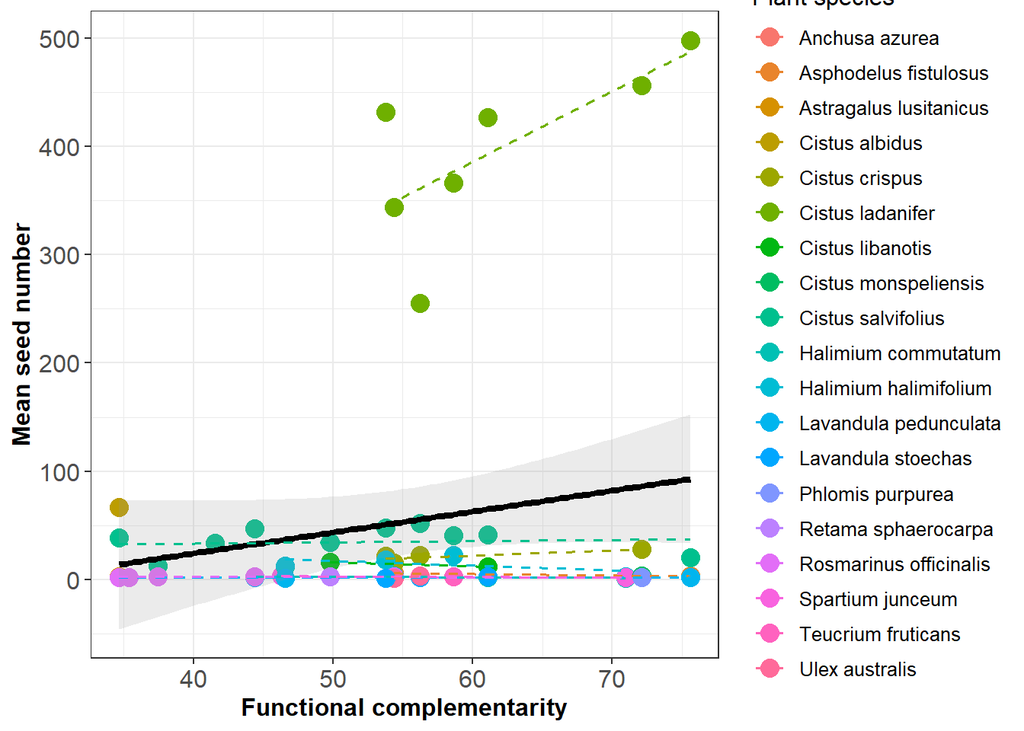

it seems all effects are driven by Cistus ladanifer, re-analyse without this species

```
##  Family: poisson  ( log )
## Formula:
## mean.seednumber ~ nodf.song * functional.comp.poll + (1 | Plant.sp)
## Data: s.agg2
##
##      AIC      BIC   logLik deviance df.resid
##    354.1    364.4   -172.1    344.1       53
##
## Random effects:
##
## Conditional model:
##  Groups   Name        Variance Std.Dev.
##  Plant.sp (Intercept) 1.305    1.142
## Number of obs: 58, groups:  Plant.sp, 18
##
## Conditional model:
##                                Estimate Std. Error z value Pr(>|z|)
## (Intercept)                    -0.15167    1.30530  -0.116   0.9075
## nodf.song                      -4.34936    3.88799  -1.119   0.2633
## functional.comp.poll            0.04374    0.02052   2.131   0.0331 *
## nodf.song:functional.comp.poll  0.11642    0.06078   1.916   0.0554 .
## ---
## Signif. codes:  0 '***' 0.001 '**' 0.01 '*' 0.05 '.' 0.1 ' ' 1
```

```
## Global model call: glmmTMB(formula = mean.seednumber ~ nodf.song * functional.comp.poll +
##     (1 | Plant.sp), data = s.agg2, family = "poisson", ziformula = ~0,
##     dispformula = ~1)
## ---
## Model selection table
##   cnd((Int)) dsp((Int)) cnd(fnc.cmp.pll) cnd(ndf.sng)
## 8    -0.1517          +        0.0437400       -4.349
## 3     2.4590          +                         2.793
## 4     2.2250          +        0.0053470        3.003
## 1     1.5860          +
## 2     1.6170          +       -0.0005522
##   cnd(fnc.cmp.pll:ndf.sng) df   logLik  AICc delta weight
## 8                   0.1164  5 -172.068 355.3  0.00  0.449
## 3                           3 -174.762 356.0  0.68  0.320
## 4                           4 -173.938 356.6  1.34  0.230
## 1                           2 -184.497 373.2 17.92  0.000
## 2                           3 -184.487 375.4 20.13  0.000
## Models ranked by AICc(x)
## Random terms (all models):
## 'cond(1 | Plant.sp)'
```

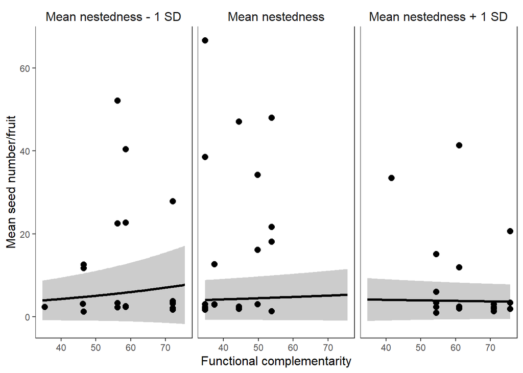

driven only by C. salvifolius and albidus? re-do analyses

```
##  Family: poisson  ( log )
## Formula:
## mean.seednumber ~ nodf.song * functional.comp.poll + (1 | Plant.sp)
## Data: s.agg3
##
##      AIC      BIC   logLik deviance df.resid
##    231.8    241.0   -110.9    221.8       42
##
## Random effects:
##
## Conditional model:
##  Groups   Name        Variance Std.Dev.
##  Plant.sp (Intercept) 1.048    1.024
## Number of obs: 47, groups:  Plant.sp, 17
##
## Conditional model:
##                                Estimate Std. Error z value Pr(>|z|)
## (Intercept)                     0.41648    2.04898   0.203    0.839
## nodf.song                      -4.23970    6.71111  -0.632    0.528
## functional.comp.poll            0.03153    0.03141   1.004    0.316
## nodf.song:functional.comp.poll  0.11488    0.10179   1.129    0.259
```

```
## Global model call: glmmTMB(formula = mean.seednumber ~ nodf.song * functional.comp.poll +
##     (1 | Plant.sp), data = s.agg3, family = "poisson", ziformula = ~0,
##     dispformula = ~1)
## ---
## Model selection table
##   cnd((Int)) dsp((Int)) cnd(fnc.cmp.pll) cnd(ndf.sng)
## 3     2.4970          +                         3.309
## 4     2.6340          +        -0.002817        3.242
## 8     0.4165          +         0.031530       -4.240
## 1     1.4660          +
## 2     2.0070          +        -0.009647
##   cnd(fnc.cmp.pll:ndf.sng) df   logLik  AICc delta weight
## 3                           3 -111.643 229.8  0.00  0.661
## 4                           4 -111.570 232.1  2.25  0.215
## 8                   0.1149  5 -110.892 233.2  3.40  0.120
## 1                           2 -118.508 241.3 11.45  0.002
## 2                           3 -117.567 241.7 11.85  0.002
## Models ranked by AICc(x)
## Random terms (all models):
## 'cond(1 | Plant.sp)'
```

```
##  Family: poisson  ( log )
## Formula:          mean.seednumber ~ nodf.song + (1 | Plant.sp)
## Data: s.agg3
##
##      AIC      BIC   logLik deviance df.resid
##    229.3    234.8   -111.6    223.3       44
##
## Random effects:
##
## Conditional model:
##  Groups   Name        Variance Std.Dev.
##  Plant.sp (Intercept) 1.057    1.028
## Number of obs: 47, groups:  Plant.sp, 17
##
## Conditional model:
##             Estimate Std. Error z value Pr(>|z|)
## (Intercept)   2.4972     0.3922   6.367 1.93e-10 ***
## nodf.song     3.3087     0.9362   3.534 0.000409 ***
## ---
## Signif. codes:  0 '***' 0.001 '**' 0.01 '*' 0.05 '.' 0.1 ' ' 1
```

```
##  Family: poisson  ( log )
## Formula:
## mean.seednumber ~ nodf.song * functional.comp.poll + (1 | Plant.sp)
## Data: s.agg4
##
##      AIC      BIC   logLik deviance df.resid
##    336.6    346.8   -163.3    326.6       52
##
## Random effects:
##
## Conditional model:
##  Groups   Name        Variance Std.Dev.
##  Plant.sp (Intercept) 0.8963   0.9468
## Number of obs: 57, groups:  Plant.sp, 17
##
## Conditional model:
##                                Estimate Std. Error z value Pr(>|z|)
## (Intercept)                    -0.50716    1.30354  -0.389   0.6972
## nodf.song                      -4.85887    3.89393  -1.248   0.2121
## functional.comp.poll            0.04697    0.02052   2.289   0.0221 *
## nodf.song:functional.comp.poll  0.12419    0.06079   2.043   0.0411 *
## ---
## Signif. codes:  0 '***' 0.001 '**' 0.01 '*' 0.05 '.' 0.1 ' ' 1
```

```
## Global model call: glmmTMB(formula = mean.seednumber ~ nodf.song * functional.comp.poll +
##     (1 | Plant.sp), data = s.agg4, family = "poisson", ziformula = ~0,
##     dispformula = ~1)
## ---
## Model selection table
##   cnd((Int)) dsp((Int)) cnd(fnc.cmp.pll) cnd(ndf.sng)
## 8    -0.5072          +        4.697e-02       -4.859
## 3     2.3060          +                         2.759
## 4     2.0380          +        6.020e-03        2.996
## 1     1.4390          +
## 2     1.4350          +        8.391e-05
##   cnd(fnc.cmp.pll:ndf.sng) df   logLik  AICc delta weight
## 8                   0.1242  5 -163.297 337.8  0.00  0.543
## 3                           3 -166.473 339.4  1.63  0.241
## 4                           4 -165.424 339.6  1.85  0.216
## 1                           2 -176.001 356.2 18.45  0.000
## 2                           3 -176.001 358.5 20.68  0.000
## Models ranked by AICc(x)
## Random terms (all models):
## 'cond(1 | Plant.sp)'
```

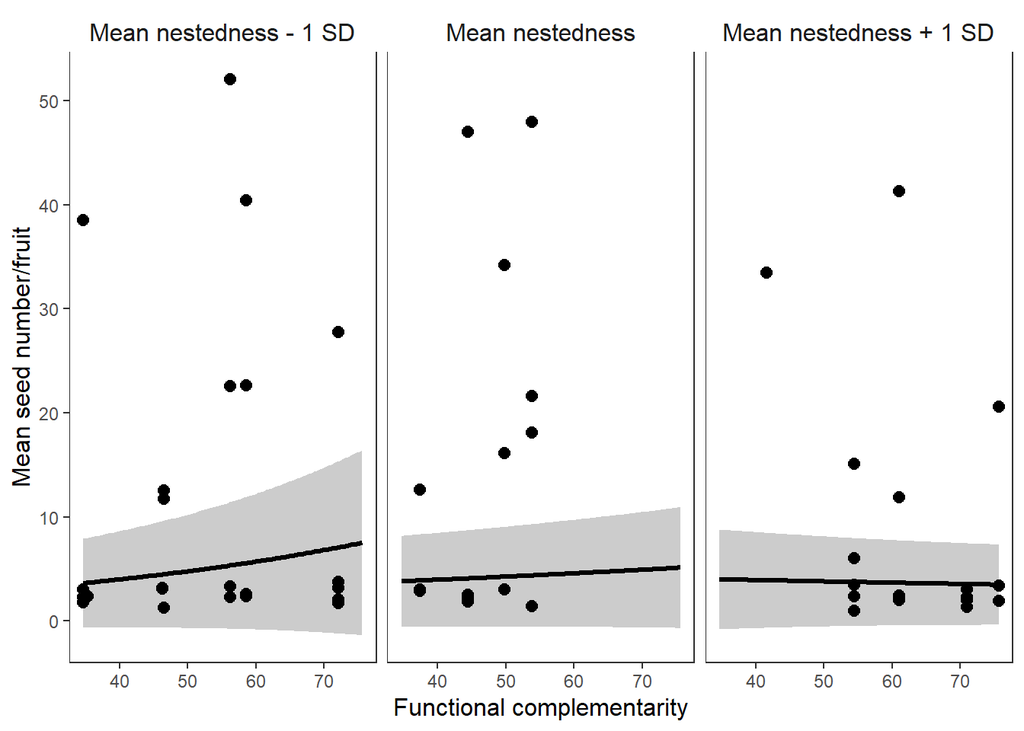

#### fUNCTION AS SEED OR FRUIT WEIGHT

```
##  Family: poisson  ( log )
## Formula:
## mean.seedweight ~ nodf.song * functional.comp.poll + (1 | Plant.sp)
## Data: s.agg
##
##      AIC      BIC   logLik deviance df.resid
##       NA       NA       NA       NA       60
##
## Random effects:
##
## Conditional model:
##  Groups   Name        Variance  Std.Dev.
##  Plant.sp (Intercept) 2.155e-18 1.468e-09
## Number of obs: 65, groups:  Plant.sp, 19
##
## Conditional model:
##                                 Estimate Std. Error z value Pr(>|z|)
## (Intercept)                     -8.81128   24.62926  -0.358    0.721
## nodf.song                      -12.38185   78.71669  -0.157    0.875
## functional.comp.poll             0.08087    0.36378   0.222    0.824
## nodf.song:functional.comp.poll   0.18698    1.14092   0.164    0.870
```

```
## Global model call: glmmTMB(formula = mean.seedweight ~ nodf.song * functional.comp.poll +
##     (1 | Plant.sp), data = s.agg, family = "poisson", ziformula = ~0,
##     dispformula = ~1)
## ---
## Model selection table
##   cnd((Int)) dsp((Int)) cnd(fnc.cmp.pll) cnd(ndf.sng)
## 1     -3.715          +
## 2     -4.948          +          0.02169
## 3     -3.998          +                       -0.8780
## 4     -4.887          +          0.02288       0.4002
## 8     -8.811          +          0.08087     -12.3800
##   cnd(fnc.cmp.pll:ndf.sng) df logLik AICc delta weight
## 1                           2 -6.646 17.5  0.00  0.545
## 2                           3 -6.591 19.6  2.09  0.192
## 3                           3 -6.641 19.7  2.19  0.182
## 4                           4 -6.590 21.8  4.36  0.062
## 8                    0.187  5 -6.576 24.2  6.68  0.019
## Models ranked by AICc(x)
## Random terms (all models):
## 'cond(1 | Plant.sp)'
```

```
##  Family: poisson  ( log )
## Formula:          mean.seedweight ~ nodf.song + (1 | Plant.sp)
## Data: s.agg
##
##      AIC      BIC   logLik deviance df.resid
##     19.3     25.8     -6.6     13.3       62
##
## Random effects:
##
## Conditional model:
##  Groups   Name        Variance Std.Dev.
##  Plant.sp (Intercept) 1.56e-09 3.949e-05
## Number of obs: 65, groups:  Plant.sp, 19
##
## Conditional model:
##             Estimate Std. Error z value Pr(>|z|)
## (Intercept)   -3.998      3.115  -1.283    0.199
## nodf.song     -0.878      9.268  -0.095    0.925
```

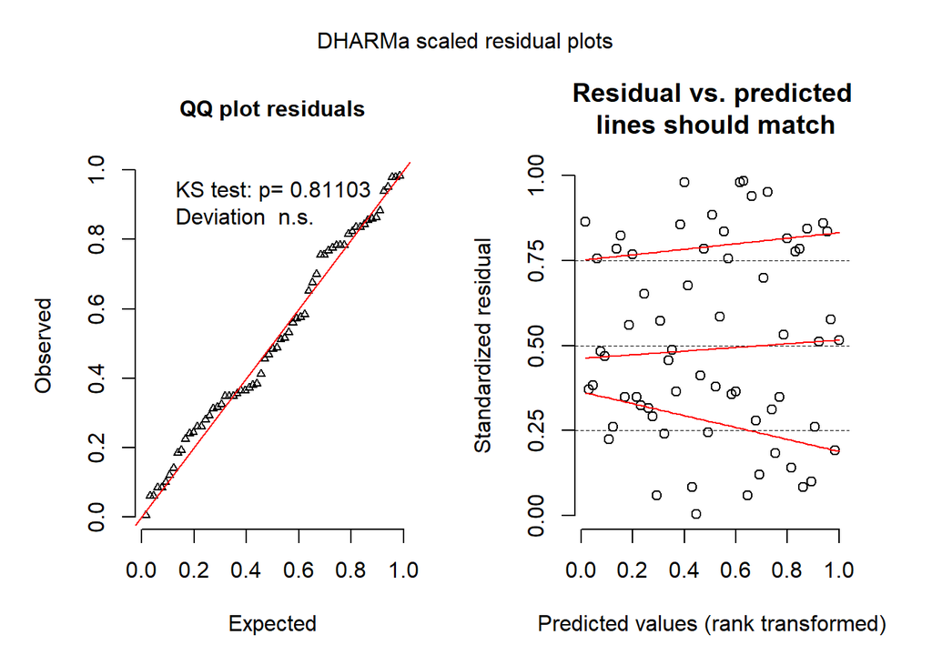

```
##  Family: nbinom2  ( log )
## Formula:
## mean.fruitweight ~ nodf.song * functional.comp.poll + (1 | Plant.sp)
## Data: s.agg
##
##      AIC      BIC   logLik deviance df.resid
##       NA       NA       NA       NA       59
##
## Random effects:
##
## Conditional model:
##  Groups   Name        Variance  Std.Dev.
##  Plant.sp (Intercept) 1.717e-09 4.144e-05
## Number of obs: 65, groups:  Plant.sp, 19
##
## Overdispersion parameter for nbinom2 family (): 1.4e+10
##
## Conditional model:
##                                Estimate Std. Error z value Pr(>|z|)
## (Intercept)                    -3.94127   11.81522  -0.334    0.739
## nodf.song                      -2.08253   38.22074  -0.054    0.957
## functional.comp.poll            0.02927    0.17976   0.163    0.871
## nodf.song:functional.comp.poll  0.04570    0.56726   0.081    0.936
```

```
## Global model call: glmmTMB(formula = mean.fruitweight ~ nodf.song * functional.comp.poll +
##     (1 | Plant.sp), data = s.agg, family = "nbinom2", ziformula = ~0,
##     dispformula = ~1)
## ---
## Model selection table
##   cnd((Int)) dsp((Int)) cnd(fnc.cmp.pll) cnd(ndf.sng)
## 1     -2.504          +
## 3     -2.484          +                       0.06261
## 2     -3.185          +          0.01274
## 4     -3.042          +          0.01505      0.85520
## 8     -3.937          +          0.02918     -2.06700
##   cnd(fnc.cmp.pll:ndf.sng) df  logLik AICc
## 1                           3 -16.892 40.2
## 3                           4 -16.892 42.5
## 2                           4
## 4                           5
## 8                  0.04547  6
## Models ranked by AICc(x)
## Random terms (all models):
## 'cond(1 | Plant.sp)'
```

```
##  Family: nbinom2  ( log )
## Formula:          mean.fruitweight ~ nodf.song + (1 | Plant.sp)
## Data: s.agg
##
##      AIC      BIC   logLik deviance df.resid
##     41.8     50.5    -16.9     33.8       61
##
## Random effects:
##
## Conditional model:
##  Groups   Name        Variance Std.Dev.
##  Plant.sp (Intercept) 0.06504  0.255
## Number of obs: 65, groups:  Plant.sp, 19
##
## Overdispersion parameter for nbinom2 family (): 5.07e+06
##
## Conditional model:
##             Estimate Std. Error z value Pr(>|z|)
## (Intercept) -2.48440    1.78979  -1.388    0.165
## nodf.song    0.06261    5.17594   0.012    0.990
```

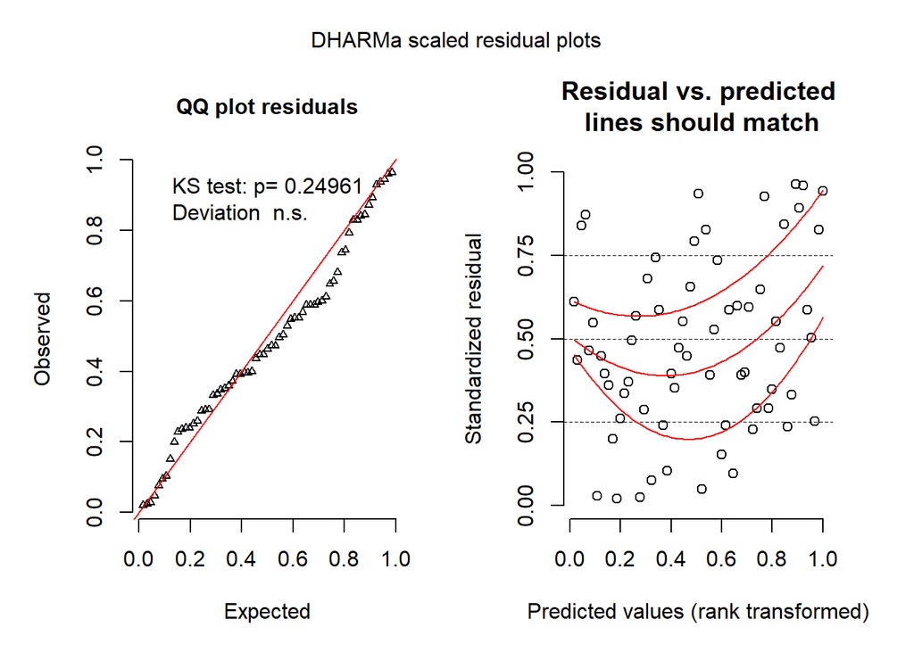

### QUESTION 2:

2. How does the position of a plant species within a network affect its reproductive success?

We will focus on the effect of networks metrics measured at the species level: normalised degree, c, z, betweenness and closeness on average fruit set per plant. This time site will be included as random to evaluate whether node position of a plant species in a particular networks affects its reproductive success.

look at cz plots to see potential connector, hub etc species, first for all plant species in the network, then only for species for which we have data on fruit set

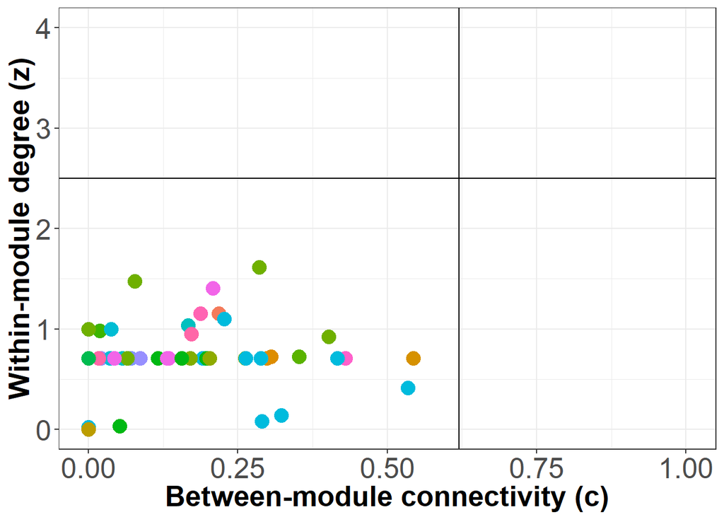

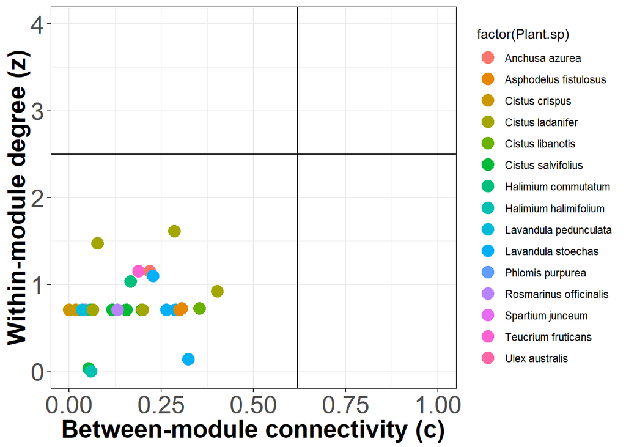

```
##  Family: gaussian  ( identity )
## Formula:
## mean.fruitset ~ norm_degree + c + z + weigh_betweeness + weigh_closeness +
##     (1 | Site_ID)
## Data: f.agg2
##
##      AIC      BIC   logLik deviance df.resid
##      5.7     19.2      5.2    -10.3       32
##
## Random effects:
##
## Conditional model:
##  Groups   Name        Variance  Std.Dev.
##  Site_ID  (Intercept) 8.401e-11 9.166e-06
##  Residual             4.521e-02 2.126e-01
## Number of obs: 40, groups:  Site_ID, 15
##
## Dispersion estimate for gaussian family (sigma^2): 0.0452
##
## Conditional model:
##                  Estimate Std. Error z value Pr(>|z|)
## (Intercept)       0.61072    0.08350   7.314 2.59e-13 ***
## norm_degree       0.08949    0.62103   0.144    0.885
## c                 0.05575    0.22206   0.251    0.802
## z                -0.01488    0.06640  -0.224    0.823
## weigh_betweeness  0.03744    0.28814   0.130    0.897
## weigh_closeness   1.79530    1.10646   1.623    0.105
## ---
## Signif. codes:  0 '***' 0.001 '**' 0.01 '*' 0.05 '.' 0.1 ' ' 1
```

```
## Global model call: glmmTMB(formula = mean.fruitset ~ norm_degree + c + z + weigh_betweeness +
##     weigh_closeness + (1 | Site_ID), data = f.agg2, family = "gaussian",
##     ziformula = ~0, dispformula = ~1)
## ---
## Model selection table
##    cnd((Int)) dsp((Int))  cnd(c) cnd(nrm_dgr) cnd(wgh_btw) cnd(wgh_cls)
## 9      0.6215          +                                          1.962
## 1      0.7554          +
## 10     0.6169          + 0.07178                                  1.850
## 13     0.6187          +                           0.06439        1.866
## 11     0.6174          +             0.061190                     1.895
## 25     0.6216          +                                          1.989
## 2      0.7229          + 0.19130
## 3      0.7098          +             0.325100
## 5      0.7290          +                           0.18290
```

[output cut: 59 more lines]

```
##  Family: gaussian  ( identity )
## Formula:          mean.fruitset ~ weigh_closeness + (1 | Site_ID)
## Data: f.agg2
##
##      AIC      BIC   logLik deviance df.resid
##     -2.1      4.6      5.1    -10.1       36
##
## Random effects:
##
## Conditional model:
##  Groups   Name        Variance  Std.Dev.
##  Site_ID  (Intercept) 2.161e-11 4.649e-06
##  Residual             4.546e-02 2.132e-01
## Number of obs: 40, groups:  Site_ID, 15
##
## Dispersion estimate for gaussian family (sigma^2): 0.0455
##
## Conditional model:
##                 Estimate Std. Error z value Pr(>|z|)
## (Intercept)      0.62147    0.07501   8.285   <2e-16 ***
## weigh_closeness  1.96153    0.98166   1.998   0.0457 *
## ---
## Signif. codes:  0 '***' 0.001 '**' 0.01 '*' 0.05 '.' 0.1 ' ' 1
```

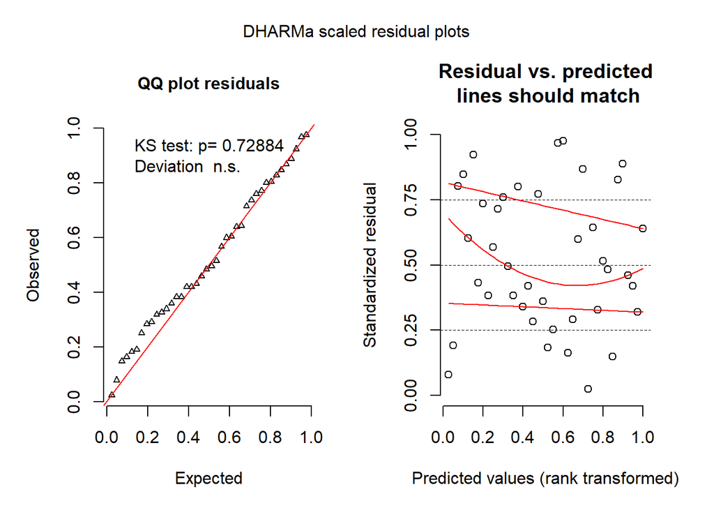

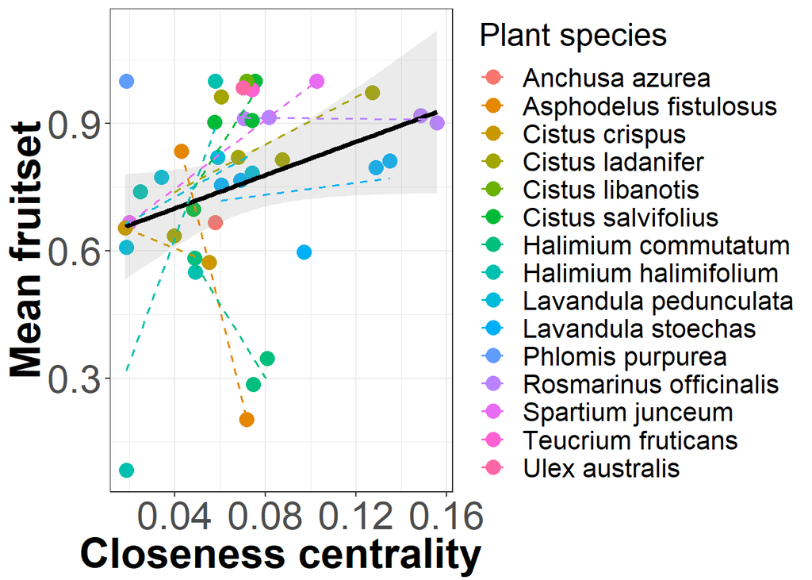

```
##  Family: gaussian  ( identity )
## Formula:
## mean.seednumber ~ norm_degree + c + z + weigh_betweeness + weigh_closeness +
##     (1 | Site_ID)
## Data: s.agg
##
##      AIC      BIC   logLik deviance df.resid
##    501.8    515.3   -242.9    485.8       32
##
## Random effects:
##
## Conditional model:
##  Groups   Name        Variance  Std.Dev.
##  Site_ID  (Intercept) 3.152e-04   0.01775
##  Residual             1.102e+04 104.95405
## Number of obs: 40, groups:  Site_ID, 15
##
## Dispersion estimate for gaussian family (sigma^2): 1.1e+04
##
## Conditional model:
##                  Estimate Std. Error z value Pr(>|z|)
## (Intercept)         83.45      41.40   2.016   0.0438 *
## norm_degree       -611.02     316.64  -1.930   0.0536 .
## c                  112.58     109.56   1.028   0.3042
## z                  142.80      33.79   4.226 2.38e-05 ***
## weigh_betweeness   -57.52     144.34  -0.398   0.6903
## weigh_closeness    -22.39     546.55  -0.041   0.9673
## ---
## Signif. codes:  0 '***' 0.001 '**' 0.01 '*' 0.05 '.' 0.1 ' ' 1
```

```
## Global model call: glmmTMB(formula = mean.seednumber ~ norm_degree + c + z + weigh_betweeness +
##     weigh_closeness + (1 | Site_ID), data = s.agg, family = "gaussian",
##     ziformula = ~0, dispformula = ~1)
## ---
## Model selection table
##    cnd((Int)) dsp((Int)) cnd(c) cnd(nrm_dgr) cnd(wgh_btw) cnd(wgh_cls)
## 27      91.31          +             -659.90                    128.60
## 28      86.73          + 100.00      -687.10                    -16.11
## 31      90.62          +             -639.40      -14.850       131.60
## 25      48.29          +                                       -313.60
## 29      56.25          +                         -184.600      -104.60
## 32      83.45          + 112.60      -611.00      -57.520       -22.39
## 30      49.69          + 131.00                  -225.500      -271.60
## 26      43.98          +  67.85                                -424.10
## 19      98.45          +             -641.90
```

[output cut: 59 more lines]

```
##  Family: gaussian  ( identity )
## Formula:
## mean.seednumber ~ norm_degree + z + weigh_closeness + (1 | Site_ID)
## Data: s.agg
##
##      AIC      BIC   logLik deviance df.resid
##    498.9    509.0   -243.4    486.9       34
##
## Random effects:
##
## Conditional model:
##  Groups   Name        Variance  Std.Dev.
##  Site_ID  (Intercept) 3.316e-04   0.01821
##  Residual             1.131e+04 106.34512
## Number of obs: 40, groups:  Site_ID, 15
##
## Dispersion estimate for gaussian family (sigma^2): 1.13e+04
##
## Conditional model:
##                 Estimate Std. Error z value Pr(>|z|)
## (Intercept)        91.31      40.82   2.237  0.02528 *
## norm_degree      -659.95     254.33  -2.595  0.00946 **
## z                 141.30      33.40   4.231 2.33e-05 ***
## weigh_closeness   128.57     531.77   0.242  0.80895
## ---
## Signif. codes:  0 '***' 0.001 '**' 0.01 '*' 0.05 '.' 0.1 ' ' 1
```

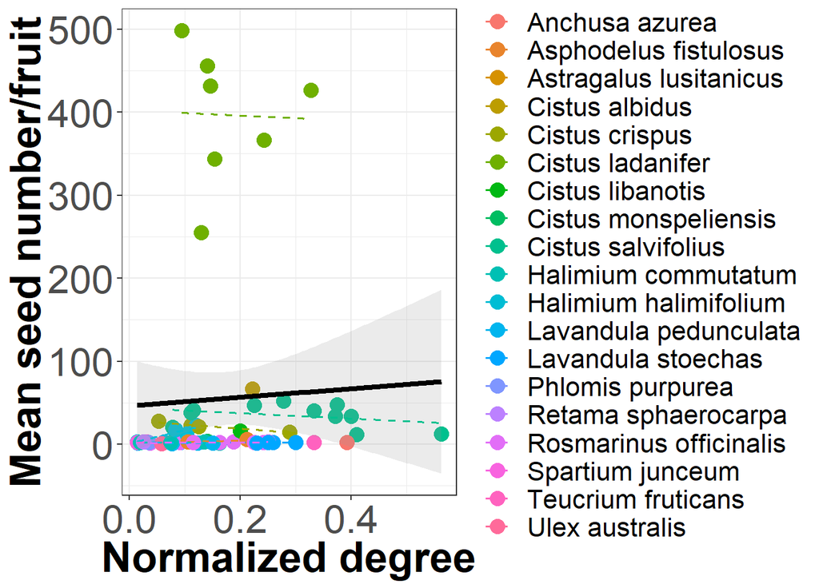

remove C. ladanifer which seems to be driving the relationship

```
##  Family: gaussian  ( identity )
## Formula:
## mean.seednumber ~ norm_degree + c + z + weigh_betweeness + weigh_closeness +
##     (1 | Site_ID)
## Data: s.agg2
##
##      AIC      BIC   logLik deviance df.resid
##       NA       NA       NA       NA       27
##
## Random effects:
##
## Conditional model:
##  Groups   Name        Variance  Std.Dev.
##  Site_ID  (Intercept) 3.442e-07 5.867e-04
##  Residual             1.301e+02 1.141e+01
## Number of obs: 35, groups:  Site_ID, 15
##
## Dispersion estimate for gaussian family (sigma^2):  130
##
## Conditional model:
##                  Estimate Std. Error z value Pr(>|z|)
## (Intercept)        14.958      4.751   3.148  0.00164 **
## norm_degree       -16.744     37.286  -0.449  0.65338
## c                  -5.670     12.849  -0.441  0.65902
## z                   7.505      4.658   1.611  0.10713
## weigh_betweeness    8.027     16.299   0.492  0.62236
## weigh_closeness   -81.100     62.700  -1.294  0.19585
## ---
## Signif. codes:  0 '***' 0.001 '**' 0.01 '*' 0.05 '.' 0.1 ' ' 1
```

```
## Global model call: glmmTMB(formula = mean.seednumber ~ norm_degree + c + z + weigh_betweeness +
##     weigh_closeness + (1 | Site_ID), data = s.agg2, family = "gaussian",
##     ziformula = ~0, dispformula = ~1)
## ---
## Model selection table
##    cnd((Int)) dsp((Int))  cnd(c) cnd(nrm_dgr) cnd(wgh_btw) cnd(wgh_cls)
## 25     13.740          +                                         -90.76
## 17      7.895          +
## 18      9.314          +  -8.957
## 21      8.425          +                           -4.4470
## 20     11.220          +  -6.343      -20.810
## 23     10.940          +              -30.750       3.1550
## 22      9.301          +  -9.057                    0.2438
## 24     11.560          +  -8.186      -28.670       6.8800
## 14     14.960          + -25.150                   35.2100       -60.09
```

[output cut: 59 more lines]

```
##  Family: gaussian  ( identity )
## Formula:          mean.seednumber ~ z + weigh_closeness + (1 | Site_ID)
## Data: s.agg2
##
##      AIC      BIC   logLik deviance df.resid
##       NA       NA       NA       NA       30
##
## Random effects:
##
## Conditional model:
##  Groups   Name        Variance  Std.Dev.
##  Site_ID  (Intercept) 3.158e-46 1.777e-23
##  Residual             1.317e+02 1.148e+01
## Number of obs: 35, groups:  Site_ID, 15
##
## Dispersion estimate for gaussian family (sigma^2):  132
##
## Conditional model:
##                 Estimate Std. Error z value Pr(>|z|)
## (Intercept)       13.740      4.197   3.274  0.00106 **
## z                  6.680      3.014   2.217  0.02665 *
## weigh_closeness  -90.765     57.112  -1.589  0.11201
## ---
## Signif. codes:  0 '***' 0.001 '**' 0.01 '*' 0.05 '.' 0.1 ' ' 1
```

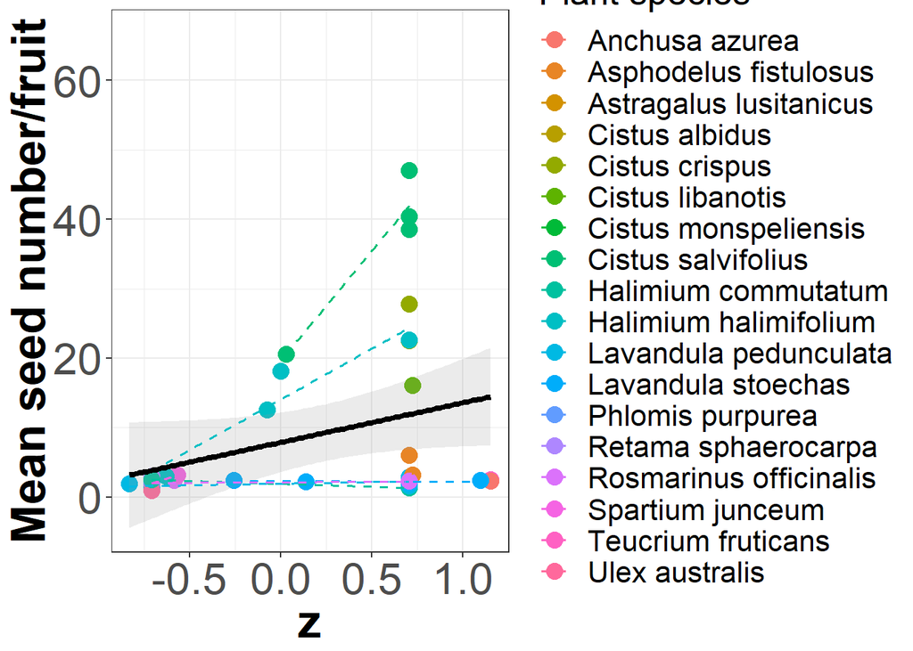

```
##  Family: gaussian  ( identity )
## Formula:
## mean.seedweight ~ norm_degree + c + z + weigh_betweeness + weigh_closeness +
##     (1 | Site_ID)
## Data: s.agg
##
##      AIC      BIC   logLik deviance df.resid
##   -144.6   -131.1     80.3   -160.6       32
##
## Random effects:
##
## Conditional model:
##  Groups   Name        Variance  Std.Dev.
##  Site_ID  (Intercept) 5.449e-13 7.382e-07
##  Residual             1.057e-03 3.251e-02
## Number of obs: 40, groups:  Site_ID, 15
##
## Dispersion estimate for gaussian family (sigma^2): 0.00106
##
## Conditional model:
##                  Estimate Std. Error z value Pr(>|z|)
## (Intercept)       0.03935    0.01282   3.069 0.002149 **
## norm_degree      -0.14862    0.09807  -1.515 0.129674
## c                 0.01583    0.03393   0.467 0.640846
## z                 0.03454    0.01047   3.300 0.000967 ***
## weigh_betweeness -0.00165    0.04471  -0.037 0.970559
## weigh_closeness  -0.14395    0.16928  -0.850 0.395133
## ---
## Signif. codes:  0 '***' 0.001 '**' 0.01 '*' 0.05 '.' 0.1 ' ' 1
```

```
## Global model call: glmmTMB(formula = mean.seedweight ~ norm_degree + c + z + weigh_betweeness +
##     weigh_closeness + (1 | Site_ID), data = s.agg, family = "gaussian",
##     ziformula = ~0, dispformula = ~1)
## ---
## Model selection table
##    cnd((Int)) dsp((Int))     cnd(c) cnd(nrm_dgr) cnd(wgh_btw) cnd(wgh_cls)
## 1     0.02435          +
## 5     0.02123          +                            0.0203700
## 3     0.01902          +                0.033540
## 2     0.02486          + -0.0004972
## 6     0.02276          + -0.0122900                 0.0232600
## 7     0.02003          +                0.011320    0.0161500
## 4     0.01973          + -0.0058940     0.035090
## 8     0.02166          + -0.0118900     0.009851    0.0194900
## 9     0.02961          +                                          -0.05853
```

[output cut: 59 more lines]

```
##  Family: gaussian  ( identity )
## Formula:          mean.seedweight ~ weigh_betweeness + (1 | Site_ID)
## Data: s.agg
##
##      AIC      BIC   logLik deviance df.resid
##   -231.0   -222.4    119.5   -239.0       59
##
## Random effects:
##
## Conditional model:
##  Groups   Name        Variance  Std.Dev.
##  Site_ID  (Intercept) 7.625e-13 8.732e-07
##  Residual             1.319e-03 3.632e-02
## Number of obs: 63, groups:  Site_ID, 16
##
## Dispersion estimate for gaussian family (sigma^2): 0.00132
##
## Conditional model:
##                  Estimate Std. Error z value Pr(>|z|)
## (Intercept)      0.021233   0.005778   3.675 0.000238 ***
## weigh_betweeness 0.020375   0.020293   1.004 0.315366
## ---
## Signif. codes:  0 '***' 0.001 '**' 0.01 '*' 0.05 '.' 0.1 ' ' 1
```

```
##  Family: gaussian  ( identity )
## Formula:
## mean.fruitweight ~ norm_degree + c + z + weigh_betweeness + weigh_closeness +
##     (1 | Site_ID)
## Data: s.agg
##
##      AIC      BIC   logLik deviance df.resid
##    -47.3    -33.8     31.7    -63.3       32
##
## Random effects:
##
## Conditional model:
##  Groups   Name        Variance  Std.Dev.
##  Site_ID  (Intercept) 3.283e-12 1.812e-06
##  Residual             1.202e-02 1.097e-01
## Number of obs: 40, groups:  Site_ID, 15
##
## Dispersion estimate for gaussian family (sigma^2): 0.012
##
## Conditional model:
##                  Estimate Std. Error z value Pr(>|z|)
## (Intercept)       0.12073    0.04325   2.791  0.00525 **
## norm_degree      -0.54183    0.33083  -1.638  0.10147
## c                 0.03272    0.11447   0.286  0.77500
## z                 0.11464    0.03531   3.247  0.00117 **
## weigh_betweeness -0.02061    0.15081  -0.137  0.89132
## weigh_closeness  -0.12824    0.57104  -0.225  0.82231
## ---
## Signif. codes:  0 '***' 0.001 '**' 0.01 '*' 0.05 '.' 0.1 ' ' 1
```

```
## Global model call: glmmTMB(formula = mean.fruitweight ~ norm_degree + c + z + weigh_betweeness +
##     weigh_closeness + (1 | Site_ID), data = s.agg, family = "gaussian",
##     ziformula = ~0, dispformula = ~1)
## ---
## Model selection table
##    cnd((Int)) dsp((Int))    cnd(c) cnd(nrm_dgr) cnd(wgh_btw) cnd(wgh_cls)
## 1     0.08466          +
## 2     0.09242          + -0.040410
## 3     0.07887          +                0.04009
## 5     0.08299          +                            0.015840
## 6     0.08983          + -0.054990                  0.028760
## 4     0.08470          + -0.048540      0.05286
## 7     0.07898          +                0.03761     0.001805
## 9     0.10180          +                                         -0.21930
## 8     0.08637          + -0.053750      0.03096     0.016920
```

[output cut: 59 more lines]

```
##  Family: gaussian  ( identity )
## Formula:          mean.fruitweight ~ c + (1 | Site_ID)
## Data: s.agg
##
##      AIC      BIC   logLik deviance df.resid
##    -80.0    -71.5     44.0    -88.0       59
##
## Random effects:
##
## Conditional model:
##  Groups   Name        Variance  Std.Dev.
##  Site_ID  (Intercept) 3.798e-12 1.949e-06
##  Residual             1.448e-02 1.203e-01
## Number of obs: 63, groups:  Site_ID, 16
##
## Dispersion estimate for gaussian family (sigma^2): 0.0145
##
## Conditional model:
##             Estimate Std. Error z value Pr(>|z|)
## (Intercept)  0.09242    0.02227   4.150 3.33e-05 ***
## c           -0.04041    0.09872  -0.409    0.682
## ---
## Signif. codes:  0 '***' 0.001 '**' 0.01 '*' 0.05 '.' 0.1 ' ' 1
```

look at cz plots for pollinator species. triangles are apis mellifera, potential there for study on their effect for repr success??

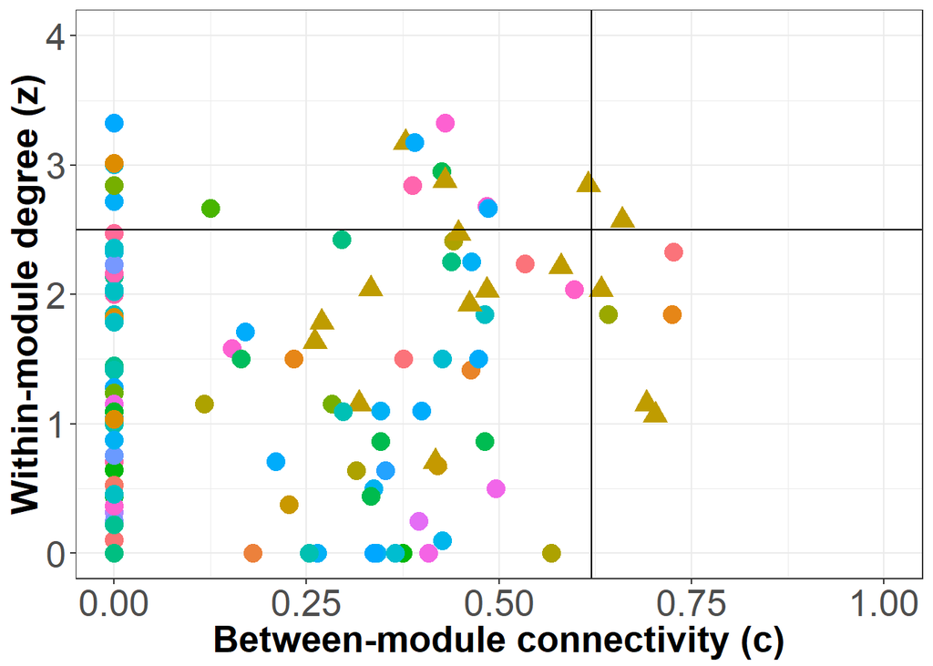

### QUESTION 3:

How does network structure affect equity in functioning?

```
##  Family: gaussian  ( identity )
## Formula:          no_rows ~ nodf.song * functional.comp.poll
## Data: f6
##
##      AIC      BIC   logLik deviance df.resid
##     58.4     62.3    -24.2     48.4       11
##
##
## Dispersion estimate for gaussian family (sigma^2):  1.2
##
## Conditional model:
##                                 Estimate Std. Error z value Pr(>|z|)
## (Intercept)                     -5.53313    4.13338  -1.339  0.18069
## nodf.song                      -16.15807   13.30936  -1.214  0.22473
## functional.comp.poll             0.19754    0.07212   2.739  0.00616 **
## nodf.song:functional.comp.poll   0.35854    0.21447   1.672  0.09458 .
## ---
## Signif. codes:  0 '***' 0.001 '**' 0.01 '*' 0.05 '.' 0.1 ' ' 1
```

```
## Global model call: glmmTMB(formula = no_rows ~ nodf.song * functional.comp.poll,
##     data = f6, family = "gaussian", ziformula = ~0, dispformula = ~1)
## ---
## Model selection table
##   cnd((Int)) dsp((Int)) cnd(fnc.cmp.pll) cnd(ndf.sng)
## 2     0.2827          +          0.06732
## 4     1.0290          +          0.08446       5.2400
## 1     3.8130          +
## 8    -5.5330          +          0.19750     -16.1600
## 3     3.6140          +                       -0.6308
##   cnd(fnc.cmp.pll:ndf.sng) df  logLik AICc delta weight
## 2                           3 -26.317 60.6  0.00  0.550
## 4                           4 -25.482 62.6  1.97  0.206
## 1                           2 -29.287 63.5  2.86  0.131
## 8                   0.3585  5 -24.194 64.4  3.76  0.084
## 3                           3 -29.277 66.6  5.92  0.029
## Models ranked by AICc(x)
```

```
##  Family: gaussian  ( identity )
## Formula:          no_rows ~ functional.comp.poll
## Data: f6
##
##      AIC      BIC   logLik deviance df.resid
##     58.6     61.0    -26.3     52.6       13
##
##
## Dispersion estimate for gaussian family (sigma^2): 1.57
##
## Conditional model:
##                      Estimate Std. Error z value Pr(>|z|)
## (Intercept)           0.28270    1.35283   0.209  0.83447
## functional.comp.poll  0.06732    0.02510   2.682  0.00732 **
## ---
## Signif. codes:  0 '***' 0.001 '**' 0.01 '*' 0.05 '.' 0.1 ' ' 1
```

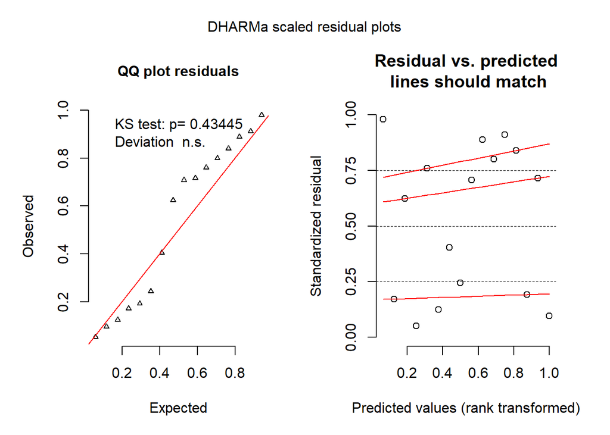

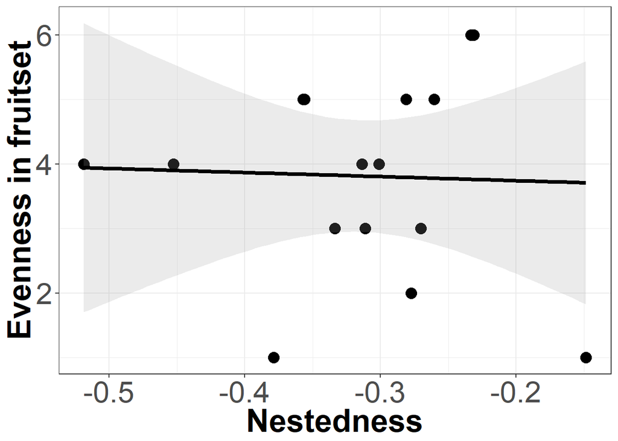

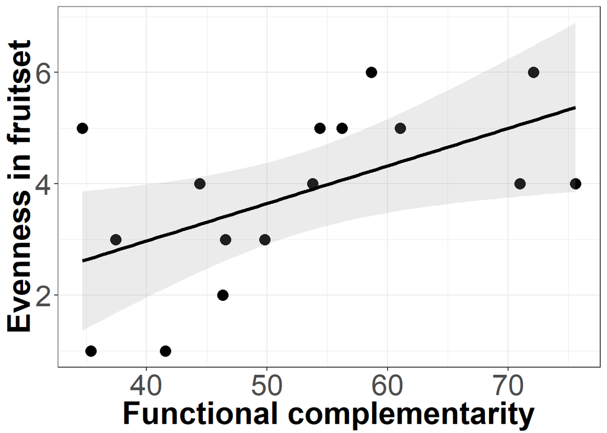

Now look at motifs and indirect interactions. To this end, we compare the roles of plant species at each site with low (<0.5) and high (>0.5) fruit set. We calculate for each plant species at each site the sum-normalised roles of all plant species in motifs up to 5 nodes and plot them using NMDS. ALthough we find a large overlap between the roles of both types ofplant species, we do find that plant species with high fruit set tend to be located in the higher values of NMDS1 which is related to network positions in which a generalist plant species interacts with highly specialized pollinator partners (e.g, positions 16 and 46, see Fig. 1 in bmotif paper, Simmons et al preprint)

```
## *** Solution reached
```

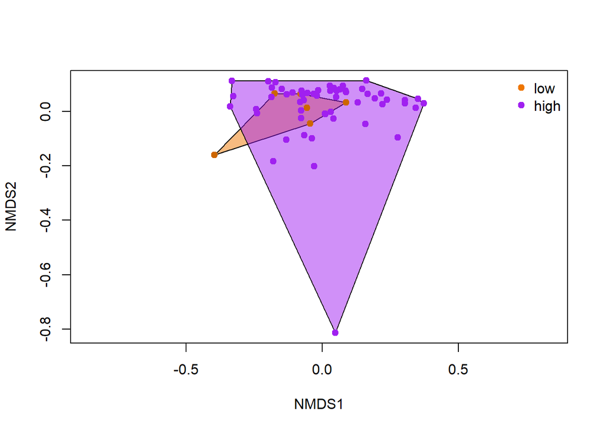